```python
import pandas as pd
```

# A. Introduction to Pandas DataFrame and Transformation (45pts)

## Beginner

### 1. Membuat DataFrame Manual (5pts)

Buatlah dataframe secara manual seperti gambar dibawah ini.

**Expected Result:**

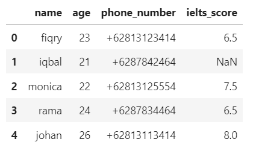

```python
## Your code below here
dataframe_manual = pd.DataFrame({'name' : ['fiqry', 'iqbal', 'monica','rama','johan'],
                                 'age' : [23, 21, 22, 24, 26],
                                 'phone_number' : ['+62813123414', '+6287842464', '+62813125554','+6287834464','+62813113414'],
                                 'ielts_score' : [6.5, None, 7.5, 6.5, 8.0],})


dataframe_manual
```

|  | name | age | phone_number | ielts_score |
| --- | --- | --- | --- | --- |
| 0 | fiqry | 23 | +62813123414 | 6.5 |
| 1 | iqbal | 21 | +6287842464 | NaN |
| 2 | monica | 22 | +62813125554 | 7.5 |
| 3 | rama | 24 | +6287834464 | 6.5 |
| 4 | johan | 26 | +62813113414 | 8.0 |

### 2. Analisa Sederhana DataFrame (10pts)

Lakukan import `application_processed.csv` data kedalam notebook (5pts) dan carilah beberapa informasi pada dataset `application_processed` (5pts) dan jawablah beberapa pertanyaan sebagai berikut:

a. Column apa saja yang memiliki nilai NaN / None? b. Berapa rata-rata pada column `amount_income_total`? c. Berapa median pada column `amount_income_total`?

**Hint**:

- Menggunakan operasi dasar DataFrame pada topik Introduction Pandas DataFrame and Transformation

```python
## Your code below here
# Mencari nilai NaN/None pada setiap kolom pada data aplication_processed.csv
dataframe_application_processed = pd.read_csv('Homework Data Processing/application_processed.csv')
kolom_null = dataframe_application_processed.isnull().sum()
result = kolom_null[kolom_null > 0]
print('Kolom dan jumlah nilai NaN pada data application_processed.csv :')
print(result)
```

```
Kolom dan jumlah nilai NaN pada data application_processed.csv :
occupation_type    40095
dtype: int64
```

```python
# mencari rata rata pada kolom amount_income_total
rata_rata_amount_income_total = dataframe_application_processed['amount_income_total'].mean()
print('Rata-rata nilai pada kolom amount_income_total :')
print(rata_rata_amount_income_total)
```

```
Rata-rata nilai pada kolom amount_income_total :
188040.57643679646
```

```python
# berapa median dari kolom amount_income_total
median_amount_income_total = dataframe_application_processed['amount_income_total'].median()
print('Median nilai pada kolom amount_income_total :')
print(median_amount_income_total)
```

```
Median nilai pada kolom amount_income_total :
162000.0
```

## Intermediate

### 3. Mengolah Dataset (30pts)

Dengan menggunakan dataset `application_processed.csv` buatlah dataframe baru dengan ketentuan:

1. Ambil semua users yang memiliki `email`. (ditandai dengan nilai pada column `flag_email` = 1) dan tidak memilik data `duplicates`. (5pts)
2. Buatlah column baru bernama `has_car_and_property` dimana nilainya merupakan range dari `0-1`. `1` apabila `flag_own_car` bernilai `1` dan `flag_own_property` bernilai `1`. `0` apabila terdapat atau semua nilai pada column `flag_own_car` dan `flag_own_property` terdapat angka 0. (5pts)
3. Ambil column yang diperlukan yaitu `id`, `gender`, `has_car_and_property`, `income_type`, `education_type`, `family_status`, `housing_type`, `occupation_type`, `amount_income_total`. (5pts)
4. Lakukan filter dengan ketentuan sebagai berikut: (5pts)
   - Memiliki `car` dan `property`
   - Tidak ada nilai null pada column `occupation_type`
   - Memiliki value pada column `occupation_type` dengan pola `staff`.
5. Sudah dilakukan sorting berdasarkan `income_type` dari `A-Z` dan `amount_income_total` dari `besar ke kecil`. (5pts)
6. Simpan kedalam bentuk `.csv` dengan nama `homework_3_result.csv`. (5pts)

**Expected Result:**

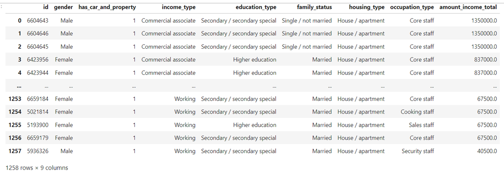

```python
dataframe_nomer_tiga = pd.read_csv(r'D:\rakamin_python\Data_Processing\Homework Data Processing\application_processed.csv')
dataframe_nomer_tiga.head(5)
```

|  | id | gender | flag_own_car | flag_own_property | total_children | amount_income_total | income_type | education_type | family_status | housing_type | days_birth | days_employed | flag_mobile_phone | flag_work_phone | flag_phone | flag_email | occupation_type | total_family_members |
| --- | --- | --- | --- | --- | --- | --- | --- | --- | --- | --- | --- | --- | --- | --- | --- | --- | --- | --- |
| 0 | 5548815 | Female | 1 | 1 | 1 | 225000.0 | State servant | Secondary / secondary special | Married | House / apartment | -12944 | -6127 | 1 | 0 | 0 | 0 | Laborers | 3.0 |
| 1 | 5692601 | Female | 1 | 1 | 0 | 180000.0 | Working | Secondary / secondary special | Married | House / apartment | -12484 | -1874 | 1 | 0 | 0 | 0 | NaN | 2.0 |
| 2 | 5625007 | Female | 1 | 0 | 0 | 157500.0 | Pensioner | Secondary / secondary special | Widow | House / apartment | -21656 | 365243 | 1 | 0 | 0 | 0 | NaN | 1.0 |
| 3 | 6529653 | Male | 0 | 1 | 0 | 202500.0 | Working | Secondary / secondary special | Married | House / apartment | -10050 | -2117 | 1 | 0 | 0 | 0 | Drivers | 2.0 |
| 4 | 6209935 | Male | 0 | 1 | 1 | 157500.0 | Commercial associate | Secondary / secondary special | Married | House / apartment | -10371 | -1755 | 1 | 0 | 0 | 0 | Drivers | 3.0 |

```python
dataframe_nomer_tiga.duplicated().any()
```

```
np.True_
```

```python
dataframe_nomer_tiga[dataframe_nomer_tiga.duplicated(keep=False) == True]
```

|  | id | gender | flag_own_car | flag_own_property | total_children | amount_income_total | income_type | education_type | family_status | housing_type | days_birth | days_employed | flag_mobile_phone | flag_work_phone | flag_phone | flag_email | occupation_type | total_family_members |
| --- | --- | --- | --- | --- | --- | --- | --- | --- | --- | --- | --- | --- | --- | --- | --- | --- | --- | --- |
| 5 | 5541414 | Female | 0 | 1 | 0 | 211500.0 | Working | Secondary / secondary special | Civil marriage | House / apartment | -18171 | -1671 | 1 | 0 | 1 | 1 | NaN | 2.0 |
| 6 | 5471417 | Female | 0 | 0 | 0 | 112500.0 | State servant | Secondary / secondary special | Married | House / apartment | -11142 | -2607 | 1 | 0 | 0 | 0 | Core staff | 2.0 |
| 7 | 5928937 | Female | 0 | 1 | 0 | 126000.0 | State servant | Secondary / secondary special | Widow | House / apartment | -22303 | -2390 | 1 | 0 | 0 | 0 | Medicine staff | 1.0 |
| 11 | 5346179 | Female | 0 | 1 | 1 | 193500.0 | Working | Secondary / secondary special | Married | House / apartment | -9895 | -1066 | 1 | 0 | 1 | 0 | Laborers | 3.0 |
| 14 | 5879182 | Female | 0 | 1 | 0 | 234000.0 | Pensioner | Secondary / secondary special | Married | House / apartment | -21193 | 365243 | 1 | 0 | 1 | 0 | NaN | 2.0 |
| ... | ... | ... | ... | ... | ... | ... | ... | ... | ... | ... | ... | ... | ... | ... | ... | ... | ... | ... |
| 131550 | 5890887 | Female | 0 | 0 | 1 | 99000.0 | Working | Secondary / secondary special | Married | House / apartment | -14684 | -1176 | 1 | 0 | 0 | 0 | Cleaning staff | 3.0 |
| 131553 | 5116166 | Female | 1 | 1 | 0 | 202500.0 | Pensioner | Secondary / secondary special | Married | House / apartment | -23390 | 365243 | 1 | 0 | 0 | 0 | NaN | 2.0 |
| 131560 | 6551037 | Male | 1 | 1 | 0 | 270000.0 | State servant | Secondary / secondary special | Married | House / apartment | -18955 | -2000 | 1 | 0 | 0 | 0 | Drivers | 2.0 |
| 131562 | 6108756 | Female | 1 | 1 | 0 | 157500.0 | Working | Higher education | Married | House / apartment | -10867 | -2637 | 1 | 0 | 0 | 0 | Managers | 2.0 |
| 131563 | 5938512 | Male | 1 | 0 | 0 | 202500.0 | Working | Secondary / secondary special | Married | House / apartment | -17815 | -5109 | 1 | 0 | 0 | 0 | NaN | 2.0 |

33799 rows × 18 columns

```python
dataframe_bersih = dataframe_nomer_tiga.drop_duplicates()
dataframe_bersih.duplicated().any()
```

```
np.False_
```

```python
dataframe_email = dataframe_bersih[dataframe_bersih['flag_email'] == 1].copy()
print(dataframe_email.shape)
print(dataframe_email['flag_email'].value_counts())
```

```
(12235, 18)
flag_email
1    12235
Name: count, dtype: int64
```

```python
dataframe_email['has_car_and_property'] = ((dataframe_email['flag_own_car'] == 1) & (dataframe_email['flag_own_property'] == 1)).astype(int)
```

```python
dataframe_email = dataframe_email[['id', 'gender', 'has_car_and_property', 'income_type','education_type', 'family_status', 'housing_type','occupation_type', 'amount_income_total']]
```

```python
dataframe_email = dataframe_email[(dataframe_email['has_car_and_property'] == 1) & (dataframe_email['occupation_type'].notnull()) & (dataframe_email['occupation_type'].str.contains('staff', case=False))]
```

```python
dataframe_email.head(5)
```

|  | id | gender | has_car_and_property | income_type | education_type | family_status | housing_type | occupation_type | amount_income_total |
| --- | --- | --- | --- | --- | --- | --- | --- | --- | --- |
| 8 | 5169560 | Female | 1 | Working | Secondary / secondary special | Married | House / apartment | Sales staff | 90000.0 |
| 23 | 6297619 | Male | 1 | Commercial associate | Higher education | Single / not married | Rented apartment | High skill tech staff | 360000.0 |
| 169 | 5548993 | Female | 1 | Commercial associate | Higher education | Married | House / apartment | Core staff | 405000.0 |
| 276 | 5344333 | Female | 1 | Working | Secondary / secondary special | Married | House / apartment | Medicine staff | 135000.0 |
| 353 | 5499766 | Female | 1 | Working | Secondary / secondary special | Civil marriage | House / apartment | Core staff | 225000.0 |

```python
dataframe_email = dataframe_email.sort_values(by=['income_type', 'amount_income_total'],ascending=[True, False])
```

```python
dataframe_email.to_csv('homework_3_result.csv', index=False)
```

# B.DataFrame Aggregation (25pts)

## Intermediate

### 4. Group By and Aggregate (10pts)

Dengan menggunakan data `titanic.csv`, buatlah dataframe untuk melihat informasi `max` dan `min` pada column `Age` dan juga informasi `mean` dan `median` pada column `Fare` pada masing-masing PassengerClass atau `Pclass`.

**Expected Result:**

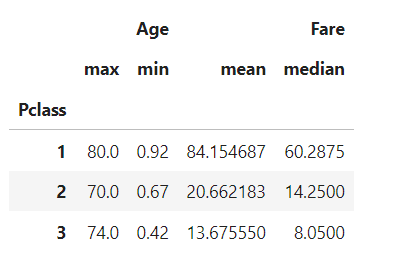

```python
dataframe_titanic = pd.read_csv(r'D:\rakamin_python\Data_Processing\Homework Data Processing\titanic.csv')
dataframe_titanic.head(5)
```

|  | PassengerId | Survived | Pclass | Name | Sex | Age | SibSp | Parch | Ticket | Fare | Cabin | Embarked |
| --- | --- | --- | --- | --- | --- | --- | --- | --- | --- | --- | --- | --- |
| 0 | 1 | 0 | 3 | Braund, Mr. Owen Harris | male | 22.0 | 1 | 0 | A/5 21171 | 7.2500 | NaN | S |
| 1 | 2 | 1 | 1 | Cumings, Mrs. John Bradley (Florence Briggs Th... | female | 38.0 | 1 | 0 | PC 17599 | 71.2833 | C85 | C |
| 2 | 3 | 1 | 3 | Heikkinen, Miss. Laina | female | 26.0 | 0 | 0 | STON/O2. 3101282 | 7.9250 | NaN | S |
| 3 | 4 | 1 | 1 | Futrelle, Mrs. Jacques Heath (Lily May Peel) | female | 35.0 | 1 | 0 | 113803 | 53.1000 | C123 | S |
| 4 | 5 | 0 | 3 | Allen, Mr. William Henry | male | 35.0 | 0 | 0 | 373450 | 8.0500 | NaN | S |

```python
result_nomer_empat = dataframe_titanic.groupby('Pclass').agg(
    max_age=('Age', 'max'),
    min_age=('Age', 'min'),
    mean_fare=('Fare', 'mean'),
    median_fare=('Fare', 'median')
).reset_index()


print(result_nomer_empat)
```

```
   Pclass  max_age  min_age  mean_fare  median_fare
0       1     80.0     0.92  84.154687      60.2875
1       2     70.0     0.67  20.662183      14.2500
2       3     74.0     0.42  13.675550       8.0500
```

### 5. Memanfaatkan Pivot Tabel (15pts)

Buatlah dataframe baru menggunakan fungsi pivot table untuk melihat `Embarked` apa saja yang `average_female_ticket_price` lebih besar daripada `average_male_ticket_price`. Informasi `average_female_ticket_price` dan `average_male_ticket_price` didapatkan dari rata-rata pada column `Fare`.

**Hint:**

1. menggunakan pivot table
2. dapat dilihat pada topik `DataFrame Aggregation` bagian `Pivot Table | Reshape Columns and Rows`

**Expected Result:**

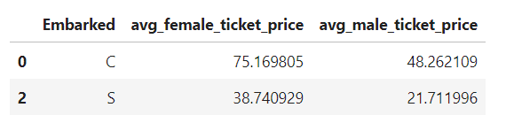

```python
dataframe_titanic = pd.read_csv(r'D:\rakamin_python\Data_Processing\Homework Data Processing\titanic.csv')

pivot_table = dataframe_titanic.pivot_table(
    values='Fare',
    index='Embarked',
    columns='Sex',
    aggfunc='mean'
).reset_index()

pivot_table['female_greater_than_male'] = pivot_table['female'] > pivot_table['male']

result = pivot_table[pivot_table['female_greater_than_male']][['Embarked', 'female', 'male']]
result.columns = ['Embarked', 'avg_female_ticket_price', 'avg_male_ticket_price']

print(result)
```

```
  Embarked  avg_female_ticket_price  avg_male_ticket_price
0        C                75.169805              48.262109
2        S                38.740929              21.711996
```

# C. DataFrame Combination (30pts)

## 6. Melakukan Append pada DataFrame (5pts)

Buatlah DataFrame seperti pada soal `no.1`. Kemudian tambahkan data tersebut dengan data users yang baru seperti gambar dibawah berikut.

**New Users Data:**

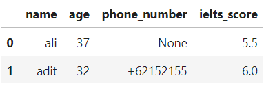

**Expected Result:**

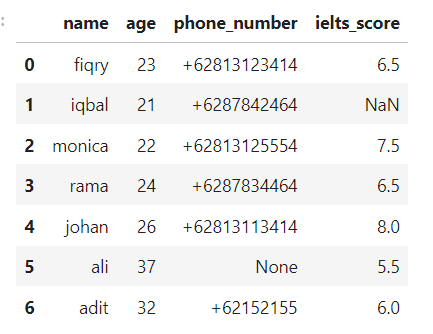

```python
dataframe_manual = pd.DataFrame({
    'name': ['fiqry', 'iqbal', 'monica', 'rama', 'johan'],
    'age': [23, 21, 22, 24, 26],
    'phone_number': ['+62813123414', '+6287842464', '+62813125554', '+6287834464', '+62813113414'],
    'ielts_score': [6.5, None, 7.5, 6.5, 8.0],
})


user_baru = pd.DataFrame({
    'name': ['ali', 'adit'],
    'age': [37, 32],
    'phone_number': [None, '+62152155'],
    'ielts_score': [5.5, 6.0],
})

dataframe_manual = pd.concat([dataframe_manual, user_baru], ignore_index=True)

print(dataframe_manual)
```

```
     name  age  phone_number  ielts_score
0   fiqry   23  +62813123414          6.5
1   iqbal   21   +6287842464          NaN
2  monica   22  +62813125554          7.5
3    rama   24   +6287834464          6.5
4   johan   26  +62813113414          8.0
5     ali   37          None          5.5
6    adit   32     +62152155          6.0
```

### 7. Merge DataFrame (25pts)

Buatlah 2 dataframe mengikuti petunjuk berikut:

df_1 : Filter dataset 01 telecom_revenue.csv dengan multiple kondisi (5pts)

- MonthlyRevenue > 10
- Occupation terdiri dari Professional, Student, and Crafts

df_2 : Filter dataset 02 telecom_usage.csv dengan multiple kondisi (5pt)

- nilai UnansweredCalls > BlockedCalls

Jawablah pertanyaan berikut ini:

1. Hitunglah total CustomerID dan rata-rata DroppedCalls untuk masing-masing occupation. (10 Points)
2. Pada occupation apa, rata-rata DroppedCalls paling besar? (5 Points)

**Expected Result:**

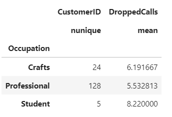

```python
df_revenue = pd.read_csv(r'D:\rakamin_python\Data_Processing\Homework Data Processing\01 telecom_revenue.csv')
df_usage = pd.read_csv(r'D:\rakamin_python\Data_Processing\Homework Data Processing\02 telecom_usage.csv')


df_1 = df_revenue[
    (df_revenue['MonthlyRevenue'] > 10) &
    (df_revenue['Occupation'].isin(['Professional', 'Student', 'Crafts']))
]


df_2 = df_usage[
    df_usage['UnansweredCalls'] > df_usage['BlockedCalls']
]

merged_df = pd.merge(df_1, df_2, on='CustomerID')

result = merged_df.groupby('Occupation').agg({
    'CustomerID': 'nunique',
    'DroppedCalls': 'mean'
})


result.columns = pd.MultiIndex.from_tuples([
    ('CustomerID', 'nunique'),
    ('DroppedCalls', 'mean')
])

print(result)
```

```
             CustomerID DroppedCalls
                nunique         mean
Occupation
Crafts               24     6.191667
Professional        128     5.532813
Student               5     8.220000
```

```python
print("Occupation dengan rata-rata DroppedCalls paling besar:")
print(result['DroppedCalls']['mean'].idxmax())
```

```
Occupation dengan rata-rata DroppedCalls paling besar:
Student
```